```python
# show plots inline
%matplotlib inline
# higher resolution graphics
%config InlineBackend.figure_format='retina'
```

# Building Kinetic Models in Python

What is a system?

> a set of interacting or interdependent components forming an integrated whole

What is a model?

> a description of a system

What is a simulation?

> an experiment performed on a model

# What are **Kinetic** Models?

Represented by differential equations

Which look something like:

$$\frac{dS_1}{dt} = f(S_1, S_2)$$

$$\frac{dS_2}{dt} = f(S_1, S_2)$$

# Using Tellurium

- [Tellurium](http://tellurium.analogmachine.org/) contains a combination of libraries to define, simulate, and analyze models.
- Models are defined using the [Antimony](http://antimony.sourceforge.net/) syntax as multi-line Python strings
- Models are loaded for simulation and analysis using [RoadRunner](http://libroadrunner.org/).

Importing the `tellurium` package.

```python
import tellurium as te # shorten tellurium to te to save typing
print te.getTelluriumVersion()
```

```
1.1.5
```

# Creating our first model

```python
myModel = '''
# Describes a system where:
# a reaction converts species S1 to species S2 at rate k1*S1

S1 -> S2; k1*S1
'''
```

- Model is a multi-line string in Antimony (a more concise model definition format)
- Single reaction defined using `Reactant -> Product` syntax
- Reaction proceeds at rate `k1*S1`

The equivalent ODEs for `S1 -> S2; k1*S1`:

$$\frac{dS_1}{dt} = -k_1S_1$$

$$\frac{dS_2}{dt} = k_1S_1$$

BUT, cannot simulate because:

No initial values of `S1` and `S2`

`k1` is not defined

The equivalent system of ordinary differential equations (ODE) represented by this scheme is:

$$\frac{dS_1}{dt} = -k_1S_1$$

$$\frac{dS_2}{dt} = k_1S_1$$

However, we currently cannot simulate this model because there are not initial values for the species `S1` and `S2`, also the parameter `k1` is not defined. Let's add these.

```python
myModel = '''
# Conversion of S1 to S2 at rate k1*S1
S1 -> S2; k1*S1

# Initial values
S1 = 10
S2 = 0
# Parameter definition
k1 = 0.1
'''
```

Note: Units are important, but left out here for simplicity, so we must be consistent, e.g. all concentrations are the same units.

# Running our First Simulation

With functions from Tellurium to help

```python
# Load the model
r = te.loadAntimonyModel(myModel)

# Carry out a time course simulation
# Arguments are:
# time start (0), time end (40), number of points (10)
result = r.simulate (0, 40, 10)

## Print column labels here
print result
```

```
[[  0.          10.           0.        ]
 [  4.           6.70319733   3.29680267]
 [  8.           4.49328603   5.50671397]
 [ 12.           3.01197194   6.98802806]
 [ 16.           2.01899061   7.98100939]
 [ 20.           1.35337474   8.64662526]
 [ 24.           0.90719877   9.09280123]
 [ 28.           0.60811502   9.39188498]
 [ 32.           0.40763322   9.59236678]
 [ 36.           0.27324597   9.72675403]
 [ 40.           0.18316275   9.81683725]]
```

The results are in multi-dimensional array.

```
  time          S1            S2
[[  0.          10.           0.        ]
 [  4.           6.70319733   3.29680267]
 [  8.           4.49328603   5.50671397]
 [ 12.           3.01197194   6.98802806]
 [ 16.           2.01899061   7.98100939]
 [ 20.           1.35337474   8.64662526]
 [ 24.           0.90719877   9.09280123]
 [ 28.           0.60811502   9.39188498]
 [ 32.           0.40763322   9.59236678]
 [ 36.           0.27324597   9.72675403]
 [ 40.           0.18316275   9.81683725]]
```

# Plotting Simulation Results

While we could analyze the raw data in many different ways, it is helpful to plot the results to quickly visualize the behavior of our system.

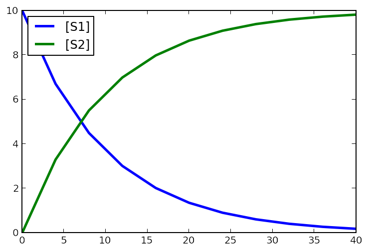

```
<module 'matplotlib.pyplot' from '/usr/lib/pymodules/python2.7/matplotlib/pyplot.pyc'>
```

```python
te.plotWithLegend(r, result)
```

Description of some of the magic commands:

- `%matplotlib inline` - show plots inline
- `%config InlineBackend.figure_format='retina'` - turns on higher resolution graphics.

Now let's see a slightly more complicated example.

# Towards More Complex Models

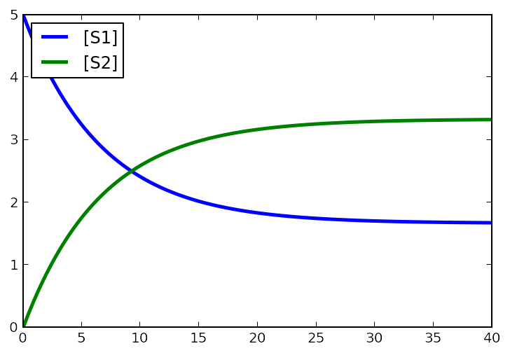

```
<module 'matplotlib.pyplot' from '/usr/lib/pymodules/python2.7/matplotlib/pyplot.pyc'>
```

```python
model = '''
S1 -> S2; k1*S1 - k2*S2 # Reversible term added here

# Initialize values
S1 = 5; S2 = 0;
k1 = 0.1;  k2 = 0.05;
'''

r = te.loadAntimonyModel(model)
result = r.simulate (0, 40, 100)
te.plotWithLegend(r, result)
```

`S1 -> S2; k1*S1 - k2*S2`

Reaction is now **reversible**. As S2 is produced, it also undergoes the reverse reaction to form S1, at the rate of $k_2S_2$.

Equivalent ODEs:

$$\frac{dS_1}{dt} = -k_1S_1 + k_2S_2$$

$$\frac{dS_2}{dt} = k_1S_1 - k_2S_2$$

Here the difference is that we made our reaction **reversible**. As S2 is produced, it also undergoes the reverse reaction to form S1, at the rate of $k_2S_2$.

The equivalent system of ordinary differential equations (ODE) is:

$$\frac{dS_1}{dt} = -k_1S_1 + k_2S_2$$

$$\frac{dS_2}{dt} = k_1S_1 - k_2S_2$$

Also note that the reverse reaction is represented above implicitly, but we could also be more verbose and explicitly define the reverse reaction. However, in either case, the underlying mathematics is the same.

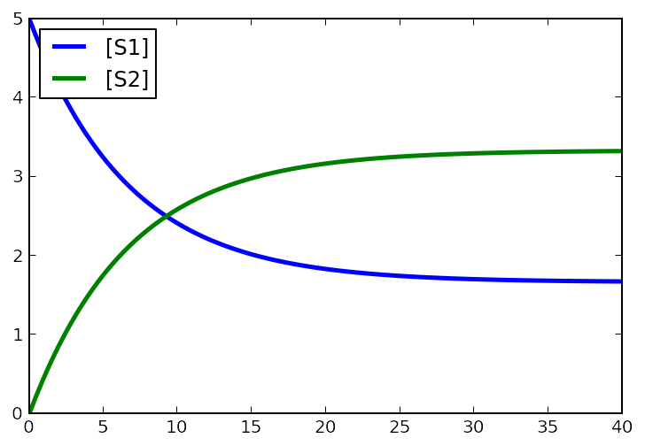

```
<module 'matplotlib.pyplot' from '/usr/lib/pymodules/python2.7/matplotlib/pyplot.pyc'>
```

```python
model = '''
S1 -> S2; k1*S1
S2 -> S1; k2*S2 # Reverse Reaction

# Initialize values
S1 = 5; S2 = 0;
k1 = 0.1;  k2 = 0.05;
'''

r = te.loadAntimonyModel(model)
result = r.simulate (0, 40, 100)
te.plotWithLegend(r, result)
```

# Equilibrium

To figure out what the equilibrium values are:

- Run the simulation "long enough" (may be tricky)
- Or, solve analytically.

# Solving for Equilibrium Analytically

We can come up with these relationships:

$$0 = \frac{dS_1}{dt} = -k_1S_1 + k_2S_2$$

$$0 = \frac{dS_2}{dt} = k_1S_1 - k_2S_2$$

$$S_1 + S_2 = S_{total}$$

Through substitution, we can come up with the equilbrium values of S1 and S2.

$$ S_1 = \frac{k_2S_{total}}{k_1 + k_2} $$

$$ S_2 = \frac{k_1S_{total}}{k_1 + k_2} $$

# Formation and degradation terms

Represented with open ended arrows

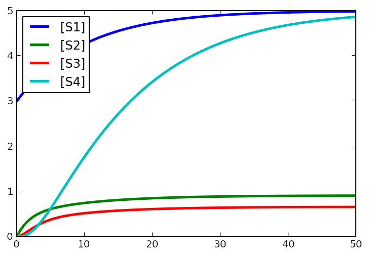

```
<module 'matplotlib.pyplot' from '/usr/lib/pymodules/python2.7/matplotlib/pyplot.pyc'>
```

```python
model = '''
   -> S1; k0    # Constant generation of S1
S1 -> S2; k1*S1
S2 -> S3; k2*S2
S3 -> S4; k3*S3
S4 ->   ; kd*S4 # Degradation of S4

# Initialize values
S1 = 3; S2 = 0; S3 = 0; S4 = 0;

k0 = 0.5; k1 = 0.1;  k2 = 0.55; k3 = 0.76; kd = 0.1;
'''

# Load the model
r = te.loadAntimonyModel(model)

result = r.simulate (0, 50, 100)
te.plotWithLegend(r, result)
```

## Tellurium provides functions for analyzing model behavior

```python
r.getSteadyStateValues()
```

```
array([ 5.        ,  0.90909091,  0.65789474,  5.        ])
```

# Inspecting the model state

```python
r.model.S1
```

```
5.000000000136823
```

```python
r.model.k1
```

```
0.1
```

# Advanced Plotting

Now let's observe the effects of changing the kinetic parameters using [small multiples](http://en.wikipedia.org/wiki/Small_multiple).

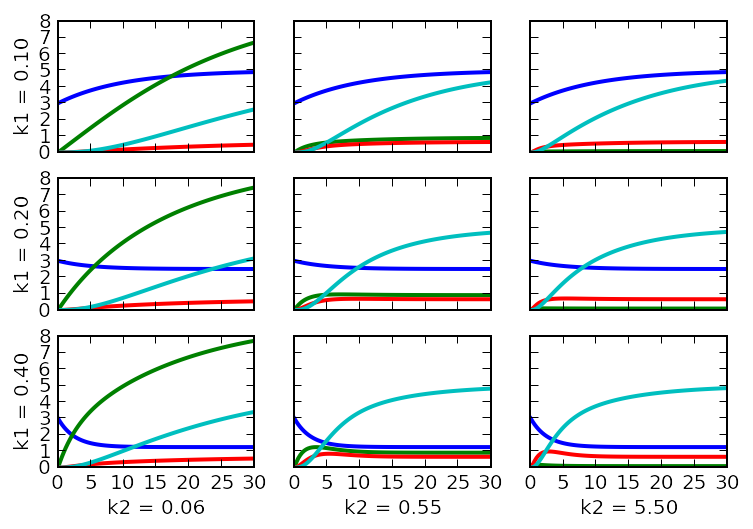

```python
import notebooktools as nb

param1 = 'k1'
param1Range = [.1, .2, .4]

param2 = 'k2'
param2Range = [0.055, 0.55, 5.5]

nb.plot2DParameterScan(r, param1, param1Range, param2, param2Range, end=30)
```

# Interactive Sliders

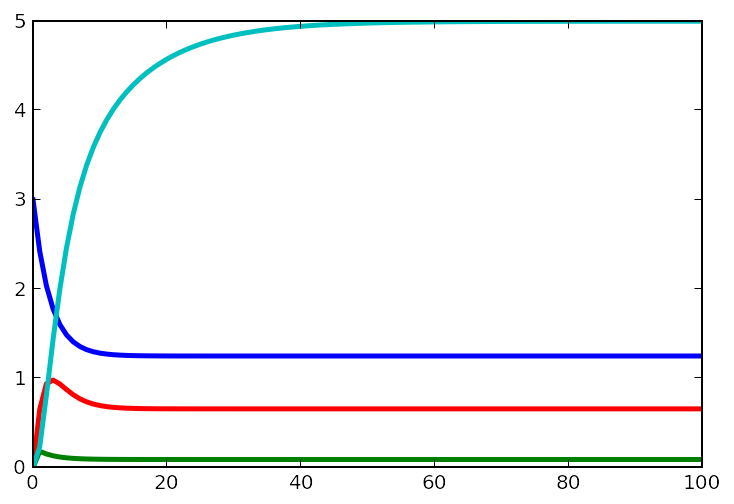

```python
nb.makeParameterSliders(r)
```

# Exporting your model

### Systems Biology Markup Language (SBML)

- Standard model exchange format
- Meant for computer programs to read
- Allows other software to make use of your model

```python
print r.getSBML()
```

```
<?xml version="1.0" encoding="UTF-8"?>
<!-- Created by libAntimony version v2.5 on 2014-09-11 16:34 with libSBML version 5.10.0. -->
<sbml xmlns="http://www.sbml.org/sbml/level3/version1/core" level="3" version="1">
  <model id="__main" name="__main">
    <listOfCompartments>
      <compartment sboTerm="SBO:0000410" id="default_compartment" spatialDimensions="3" size="1" constant="true"/>
    </listOfCompartments>
    <listOfSpecies>
      <species id="S1" compartment="default_compartment" initialConcentration="3" hasOnlySubstanceUnits="false" boundaryCondition="false" constant="false"/>
      <species id="S2" compartment="default_compartment" initialConcentration="0" hasOnlySubstanceUnits="false" boundaryCondition="false" constant="false"/>
      <species id="S3" compartment="default_compartment" initialConcentration="0" hasOnlySubstanceUnits="false" boundaryCondition="false" constant="false"/>
      <species id="S4" compartment="default_compartment" initialConcentration="0" hasOnlySubstanceUnits="false" boundaryCondition="false" constant="false"/>
    </listOfSpecies>
    <listOfParameters>
      <parameter id="k0" value="0.5" constant="true"/>
      <parameter id="k1" value="0.1" constant="true"/>
      <parameter id="k2" value="0.55" constant="true"/>
      <parameter id="k3" value="0.76" constant="true"/>
      <parameter id="kd" value="0.1" constant="true"/>
    </listOfParameters>
    <listOfReactions>
      <reaction id="_J0" reversible="true" fast="false">
        <listOfProducts>
          <speciesReference species="S1" stoichiometry="1" constant="true"/>
        </listOfProducts>
        <kineticLaw>
          <math xmlns="http://www.w3.org/1998/Math/MathML">
            <ci> k0 </ci>
          </math>
        </kineticLaw>
      </reaction>
      <reaction id="_J1" reversible="true" fast="false">
        <listOfReactants>
          <speciesReference species="S1" stoichiometry="1" constant="true"/>
        </listOfReactants>
        <listOfProducts>
          <speciesReference species="S2" stoichiometry="1" constant="true"/>
        </listOfProducts>
        <kineticLaw>
          <math xmlns="http://www.w3.org/1998/Math/MathML">
```

[output cut: 44 more lines]

```
          <speciesReference species="S4" stoichiometry="1" constant="true"/>
        </listOfReactants>
        <kineticLaw>
          <math xmlns="http://www.w3.org/1998/Math/MathML">
            <apply>
              <times/>
              <ci> kd </ci>
              <ci> S4 </ci>
            </apply>
          </math>
        </kineticLaw>
      </reaction>
    </listOfReactions>
  </model>
</sbml>
```

### Export into MATLAB

```python
print r.getMatlab()
```

```
%  How to use:
%
%  __main takes 3 inputs and returns 3 outputs.
%
%  [t x rInfo] = __main(tspan,solver,options)
%  INPUTS:
%  tspan - the time vector for the simulation. It can contain every time point,
%  or just the start and end (e.g. [0 1 2 3] or [0 100]).
%  solver - the function handle for the odeN solver you wish to use (e.g. @ode23s).
%  options - this is the options structure returned from the MATLAB odeset
%  function used for setting tolerances and other parameters for the solver.
%
%  OUTPUTS:
%  t - the time vector that corresponds with the solution. If tspan only contains
%  the start and end times, t will contain points spaced out by the solver.
%  x - the simulation results.
%  rInfo - a structure containing information about the model. The fields
%  within rInfo are:
%     stoich - the stoichiometry matrix of the model
%     floatingSpecies - a cell array containing floating species name, initial
%     value, and indicator of the units being inconcentration or amount
%     compartments - a cell array containing compartment names and volumes
%     params - a cell array containing parameter names and values
%     boundarySpecies - a cell array containing boundary species name, initial
%     value, and indicator of the units being inconcentration or amount
%     rateRules - a cell array containing the names of variables used in a rate rule
%
%  Sample function call:
%     options = odeset('RelTol',1e-12,'AbsTol',1e-9);
%     [t x rInfo] = __main(linspace(0,100,100),@ode23s,options);
%
function [t x rInfo] = __main(tspan,solver,options)
    % initial conditions
    [x rInfo] = model();

    % initial assignments

    % assignment rules

    % run simulation
```

[output cut: 180 more lines]

```
		  z = 0;
		end



function z = not(a)
   if a == 1
   	  z = 0;
   else
      z = 1;
   end


function z = root(a,b)
	z = a^(1/b);
```